# Taller 3: Regresion Lineal Simple

Bioestadistica Fundamental

Andres Felipe Florez Rivera

2026-06-24

Universidad Nacional de Colombia — Departamento de Estadistica, Sede Bogota

Este taller acompana la Clase 16 de Bioestadistica Fundamental. Trabajamos con el mismo ejemplo visto en clase: la relacion entre la dosis de nitrogeno aplicada (kg/ha) y el rendimiento del maiz (t/ha). El objetivo es implementar en R cada etapa del analisis de regresion lineal simple estudiada teoricamente.

## 1. El modelo de regresion lineal simple

En la clase se estudio que la relacion entre una variable respuesta $Y$ y una variable explicativa $X$ puede resumirse mediante:

$$Y_i = \beta_0 + \beta_1 X_i + e_i, \quad
e_i \sim N(0, \sigma^2)$$

donde:

- $\beta_0$: intercepto — valor esperado de $Y$ cuando $X = 0$.
- $\beta_1$: pendiente — cambio promedio en $Y$ por cada unidad adicional de $X$.
- $e_i$: error aleatorio, independiente, con media cero y varianza constante $\sigma^2$.

Los parametros se estiman por **Minimos Cuadrados Ordinarios (MCO)**:

$$\hat{\beta}_1 = b_1 =
\frac{\sum_{i=1}^{n}(X_i - \bar{X})(Y_i - \bar{Y})}{\sum_{i=1}^{n}(X_i -
\bar{X})^2}, \qquad \hat{\beta}_0 = b_0 = \bar{Y} - b_1
\bar{X}$$

## 2. Datos del ejemplo

Los datos corresponden al experimento de fertilizacion nitrogenada visto en clase.

| Dosis N (kg/ha) | Rendimiento (t/ha) |
| --- | --- |
| 40 | 4.2 |
| 60 | 4.8 |
| 80 | 5.3 |
| 100 | 5.9 |
| 120 | 6.4 |
| 140 | 6.8 |
| 160 | 7.3 |
| 180 | 7.8 |

```r
nitrogeno   <- c(40, 60, 80, 100, 120, 140, 160, 180)
rendimiento <- c(4.2, 4.8, 5.3, 5.9, 6.4, 6.8, 7.3, 7.8)

datos <- data.frame(nitrogeno, rendimiento)

mostrar_tabla(datos, caption = "Dosis de nitrogeno y rendimiento del maiz")
```

Dosis de nitrogeno y rendimiento del maiz

| nitrogeno | rendimiento |
| --- | --- |
| 40 | 4.2 |
| 60 | 4.8 |
| 80 | 5.3 |
| 100 | 5.9 |
| 120 | 6.4 |
| 140 | 6.8 |
| 160 | 7.3 |
| 180 | 7.8 |

## 3. Exploracion inicial de los datos

Antes de ajustar el modelo es importante explorar las variables y visualizar su relacion.

### 3.1 Estadisticas descriptivas

```r
summary(datos)
```

```
##    nitrogeno    rendimiento
##  Min.   : 40   Min.   :4.200
##  1st Qu.: 75   1st Qu.:5.175
##  Median :110   Median :6.150
##  Mean   :110   Mean   :6.062
##  3rd Qu.:145   3rd Qu.:6.925
##  Max.   :180   Max.   :7.800
```

### 3.2 Correlacion de Pearson

```r
r <- cor(datos$nitrogeno, datos$rendimiento)
cat("Correlacion de Pearson r =", round(r, 4), "\n")
```

```
## Correlacion de Pearson r = 0.9988
```

> **Interpretacion:** un valor de $r$ cercano a 1 indica una relacion lineal positiva fuerte entre la dosis de nitrogeno y el rendimiento. Esto sugiere que un modelo lineal es apropiado.

### 3.3 Diagrama de dispersion

En clase se mostro que el diagrama de dispersion permite identificar la **direccion**, la **intensidad** y la **forma** de la relacion entre variables.

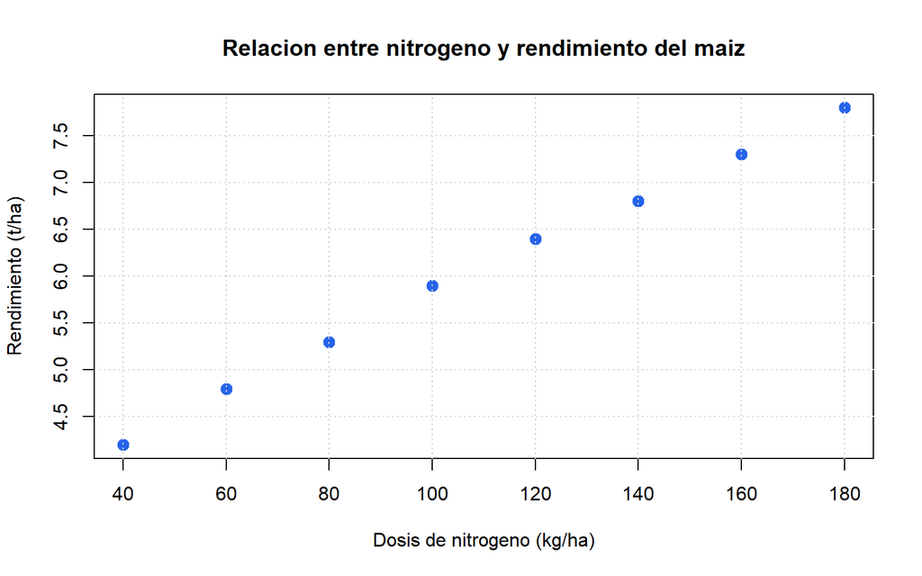

```r
plot(
  rendimiento ~ nitrogeno,
  data  = datos,
  pch   = 19,
  col   = "#2563eb",
  cex   = 1.3,
  xlab  = "Dosis de nitrogeno (kg/ha)",
  ylab  = "Rendimiento (t/ha)",
  main  = "Relacion entre nitrogeno y rendimiento del maiz"
)
grid()
```

> A medida que aumenta la dosis de nitrogeno, el rendimiento del cultivo aumenta. La tendencia parece aproximadamente lineal.

## 4. Ajuste del modelo con `lm()`

La funcion `lm()` ajusta el modelo de regresion lineal por MCO. La sintaxis basica es:

```r
modelo <- lm(Y ~ X, data = datos)
```

```r
modelo <- lm(rendimiento ~ nitrogeno, data = datos)
```

### 4.1 Resumen completo con `summary()`

```r
summary(modelo)
```

```
##
## Call:
## lm(formula = rendimiento ~ nitrogeno, data = datos)
##
## Residuals:
##      Min       1Q   Median       3Q      Max
## -0.08333 -0.03542 -0.01250  0.02708  0.09167
##
## Coefficients:
##              Estimate Std. Error t value Pr(>|t|)
## (Intercept) 3.2666667  0.0603259   54.15 2.66e-09 ***
## nitrogeno   0.0254167  0.0005062   50.21 4.19e-09 ***
## ---
## Signif. codes:  0 '***' 0.001 '**' 0.01 '*' 0.05 '.' 0.1 ' ' 1
##
## Residual standard error: 0.06562 on 6 degrees of freedom
## Multiple R-squared:  0.9976, Adjusted R-squared:  0.9972
## F-statistic:  2521 on 1 and 6 DF,  p-value: 4.188e-09
```

El resumen reporta:

- **Coefficients:** estimaciones de $b_0$ y $b_1$, errores estandar, estadistico $t$ y valor $p$.
- **Residual standard error:** estimacion de $\sigma$ (error estandar residual).
- **Multiple R-squared ($R^2$):** proporcion de variabilidad de $Y$ explicada por el modelo.
- **F-statistic:** prueba global de significancia del modelo.

### 4.2 Extraccion de coeficientes

```r
b0 <- coef(modelo)[1]
b1 <- coef(modelo)[2]

cat("Intercepto b0 =", round(b0, 4), "\n")
```

```
## Intercepto b0 = 3.2667
```

```r
cat("Pendiente  b1 =", round(b1, 4), "\n")
```

```
## Pendiente  b1 = 0.0254
```

```r
cat("\nModelo estimado: rendimiento =", round(b0, 4), "+", round(b1, 4), "* nitrogeno\n")
```

```
##
## Modelo estimado: rendimiento = 3.2667 + 0.0254 * nitrogeno
```

## 5. Bondad de ajuste e inferencia

### 5.1 Coeficiente de determinacion $R^2$

En clase se definio:

$$R^2 = 1 - \frac{SCR}{SCT} =
\frac{SCM}{SCT}$$

donde SCR es la Suma de Cuadrados Residual, SCM la del Modelo y SCT la Total.

```r
r2   <- summary(modelo)$r.squared
r2aj <- summary(modelo)$adj.r.squared

cat("R^2          =", round(r2, 4), "\n")
```

```
## R^2          = 0.9976
```

```r
cat("R^2 ajustado =", round(r2aj, 4), "\n")
```

```
## R^2 ajustado = 0.9972
```

```r
cat("El modelo explica el", round(r2 * 100, 1), "% de la variabilidad del rendimiento.\n")
```

```
## El modelo explica el 99.8 % de la variabilidad del rendimiento.
```

### 5.2 Intervalos de confianza para los coeficientes

```r
confint(modelo, level = 0.95)
```

```
##                  2.5 %    97.5 %
## (Intercept) 3.11905440 3.4142789
## nitrogeno   0.02417793 0.0266554
```

Un IC del 95% para $\beta_1$ que **no contenga el cero** indica que la pendiente es estadisticamente significativa al nivel del 5%.

### 5.3 Prueba de hipotesis sobre la pendiente

En clase se planteo:

$$H_0: \beta_1 = 0 \quad \text{vs} \quad
H_1: \beta_1 \neq 0$$

El estadistico de prueba es $t = \hat{\beta}_1 / SE(\hat{\beta}_1)$. Se rechaza $H_0$ cuando el valor $p < 0.05$.

```r
resumen    <- summary(modelo)
tabla_coef <- as.data.frame(resumen$coefficients)
names(tabla_coef) <- c("Estimado", "Error_std", "t_valor", "p_valor")
tabla_coef[, 1:4] <- round(tabla_coef[, 1:4], 6)
tabla_coef$Significativo <- ifelse(tabla_coef$p_valor < 0.05, "Si", "No")
mostrar_tabla(tabla_coef, caption = "Coeficientes del modelo con inferencia")
```

Coeficientes del modelo con inferencia

|  | Estimado | Error_std | t_valor | p_valor | Significativo |
| --- | --- | --- | --- | --- | --- |
| (Intercept) | 3.266667 | 0.060326 | 54.15028 | 0 | Si |
| nitrogeno | 0.025417 | 0.000506 | 50.20635 | 0 | Si |

## 6. Visualizacion de la recta ajustada

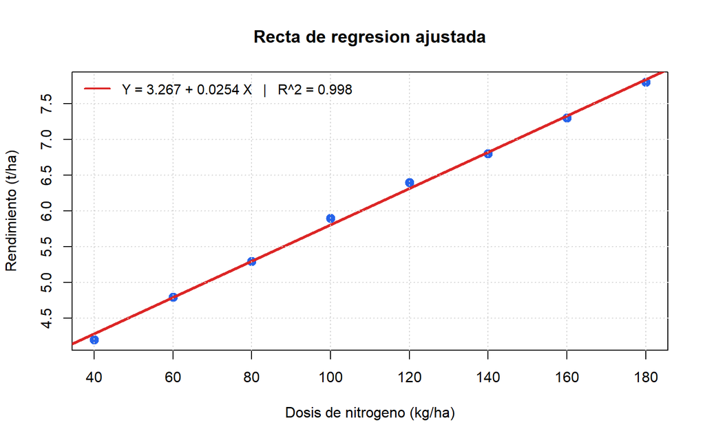

```r
plot(
  rendimiento ~ nitrogeno,
  data = datos,
  pch  = 19,
  col  = "#2563eb",
  cex  = 1.3,
  xlab = "Dosis de nitrogeno (kg/ha)",
  ylab = "Rendimiento (t/ha)",
  main = "Recta de regresion ajustada"
)
abline(modelo, col = "#dc2626", lwd = 3)
grid()
legend(
  "topleft",
  legend = paste0("Y = ", round(b0, 3), " + ", round(b1, 4), " X   |   R^2 = ", round(r2, 3)),
  col    = "#dc2626",
  lwd    = 2,
  bty    = "n",
  cex    = 0.95
)
```

## 7. Diagnostico de residuos

En clase se establecio que los supuestos del modelo son:

1. **Linealidad:** $E(Y|X) = \beta_0 + \beta_1 X$.
2. **Independencia:** los errores $e_i$ son independientes entre si.
3. **Homocedasticidad:** $\text{Var}(e_i) = \sigma^2$ constante.
4. **Normalidad:** $e_i \sim N(0, \sigma^2)$.

### 7.1 Graficos de diagnostico

Los cuatro graficos de `plot(modelo)` permiten evaluar visualmente los supuestos:

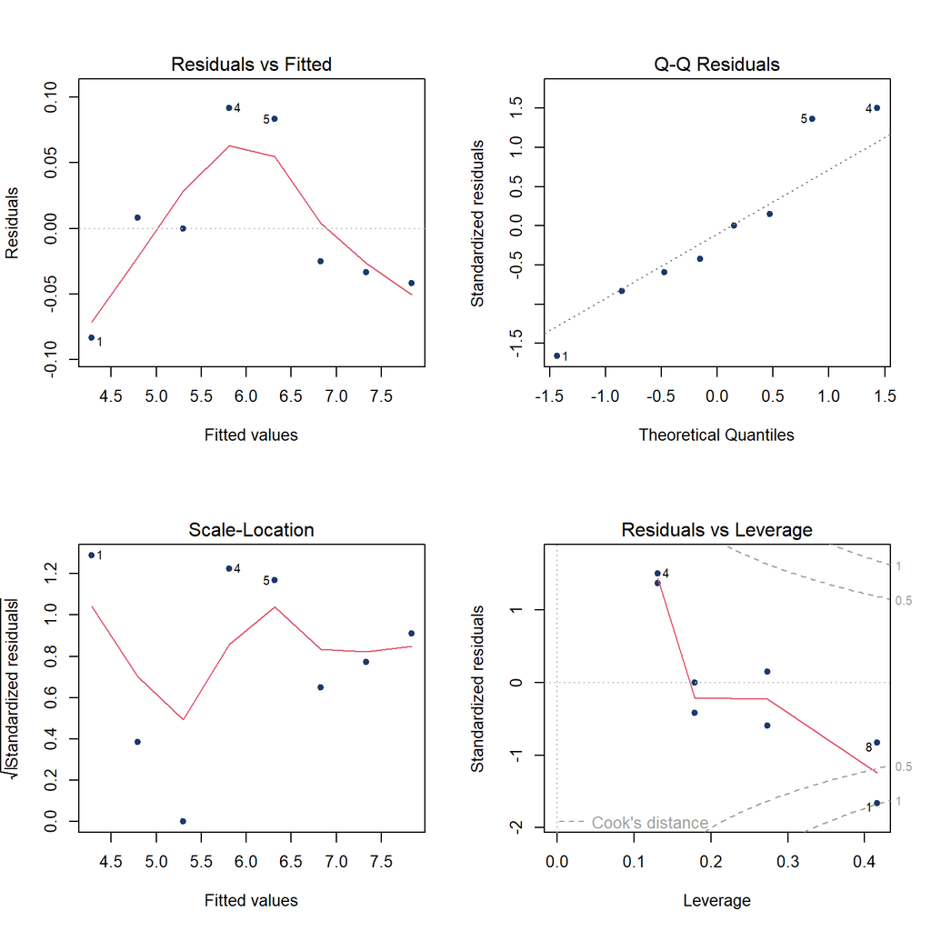

```r
par(mfrow = c(2, 2))
plot(modelo, col = "#1a3a6b", pch = 19, cex = 0.8)
```

```r
par(mfrow = c(1, 1))
```

**Lectura de los graficos (como en clase):**

- **Residuals vs Fitted:** puntos distribuidos aleatoriamente alrededor de cero indican linealidad y homocedasticidad. Patrones curvos o en embudo son senales de alerta.
- **Normal Q-Q:** los puntos deben seguir la diagonal. Desviaciones importantes sugieren falta de normalidad.
- **Scale-Location:** verifica homocedasticidad; la dispersion debe mantenerse constante.
- **Residuals vs Leverage:** identifica observaciones influyentes (distancia de Cook).

### 7.2 Extraccion de residuos y valores ajustados

```r
datos$y_hat    <- fitted(modelo)
datos$residuos <- residuals(modelo)
datos$res_std  <- rstandard(modelo)

mostrar_tabla(datos, caption = "Valores ajustados y residuos del modelo")
```

Valores ajustados y residuos del modelo

| nitrogeno | rendimiento | y_hat | residuos | res_std |
| --- | --- | --- | --- | --- |
| 40 | 4.2 | 4.283333 | -0.0833333 | -1.6628220 |
| 60 | 4.8 | 4.791667 | 0.0083333 | 0.1490318 |
| 80 | 5.3 | 5.300000 | 0.0000000 | 0.0000000 |
| 100 | 5.9 | 5.808333 | 0.0916667 | 1.4985632 |
| 120 | 6.4 | 6.316667 | 0.0833333 | 1.3623302 |
| 140 | 6.8 | 6.825000 | -0.0250000 | -0.4203785 |
| 160 | 7.3 | 7.333333 | -0.0333333 | -0.5961271 |
| 180 | 7.8 | 7.841667 | -0.0416667 | -0.8314110 |

### 7.3 Prueba de normalidad de Shapiro-Wilk

En clase se menciono esta prueba para evaluar el supuesto de normalidad de los errores.

```r
sw <- shapiro.test(residuals(modelo))
cat("Estadistico W =", round(sw$statistic, 4), "\n")
```

```
## Estadistico W = 0.9196
```

```r
cat("Valor p       =", round(sw$p.value, 4), "\n")
```

```
## Valor p       = 0.4267
```

```r
cat(ifelse(sw$p.value > 0.05,
           "No se rechaza H0: los residuos son compatibles con normalidad.",
           "Se rechaza H0: los residuos no siguen una distribucion normal."), "\n")
```

```
## No se rechaza H0: los residuos son compatibles con normalidad.
```

### 7.4 Prueba de Breusch-Pagan (homocedasticidad)

```r
library(lmtest)
bptest(modelo)
```

```
##
##  studentized Breusch-Pagan test
##
## data:  modelo
## BP = 0.51281, df = 1, p-value = 0.4739
```

> Si el valor $p > 0.05$, no se rechaza la hipotesis de varianza constante (homocedasticidad).

### 7.5 Prueba de Durbin-Watson (independencia)

```r
dwtest(modelo)
```

```
##
##  Durbin-Watson test
##
## data:  modelo
## DW = 1.1156, p-value = 0.01917
## alternative hypothesis: true autocorrelation is greater than 0
```

> Si el valor $p > 0.05$, hay evidencia de independencia en los residuos.

### 7.6 Histograma y Q-Q plot de residuos

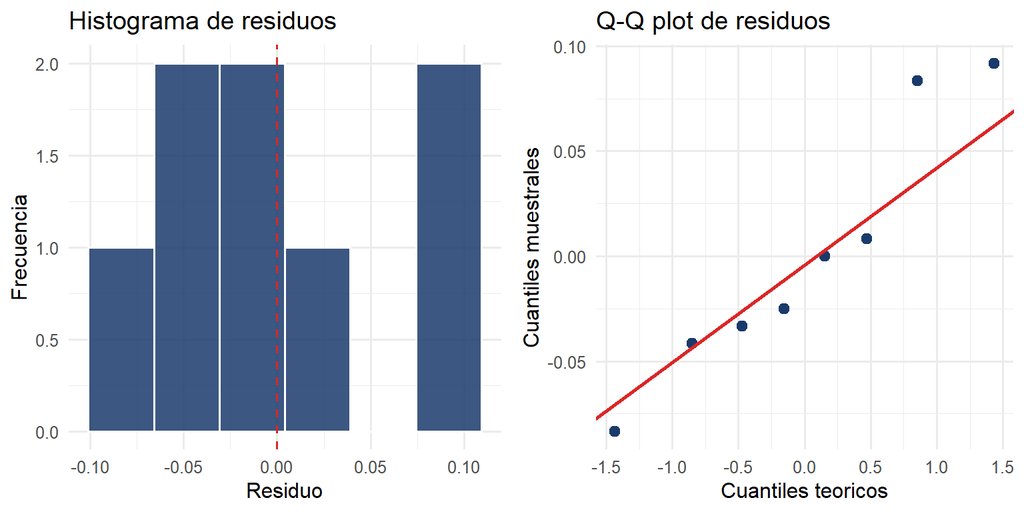

```r
library(ggplot2)

p1 <- ggplot(datos, aes(x = residuos)) +
  geom_histogram(bins = 6, fill = "#1a3a6b", color = "white", alpha = 0.85) +
  geom_vline(xintercept = 0, color = "#dc2626", linetype = "dashed") +
  labs(title = "Histograma de residuos", x = "Residuo", y = "Frecuencia") +
  theme_minimal(base_size = 12)

p2 <- ggplot(datos, aes(sample = residuos)) +
  stat_qq(color = "#1a3a6b", size = 2.5) +
  stat_qq_line(color = "#dc2626", linewidth = 0.9) +
  labs(title = "Q-Q plot de residuos",
       x = "Cuantiles teoricos", y = "Cuantiles muestrales") +
  theme_minimal(base_size = 12)

gridExtra::grid.arrange(p1, p2, ncol = 2)
```

## 8. Prediccion con `predict()`

### 8.1 Prediccion puntual

```r
nuevos <- data.frame(nitrogeno = c(50, 110, 170, 200))
pred   <- predict(modelo, newdata = nuevos)

resultado <- cbind(nuevos, rendimiento_predicho = round(pred, 3))
mostrar_tabla(resultado, caption = "Predicciones puntuales del rendimiento")
```

Predicciones puntuales del rendimiento

| nitrogeno | rendimiento_predicho |
| --- | --- |
| 50 | 4.537 |
| 110 | 6.062 |
| 170 | 7.588 |
| 200 | 8.350 |

### 8.2 Intervalos de confianza e intervalos de prediccion

En clase se establecio la diferencia:

- **Intervalo de confianza (IC):** estima donde esta la **media** de $Y$ para un $X$ dado.
- **Intervalo de prediccion (IP):** estima donde caera una **observacion individual** futura; siempre es mas ancho que el IC.

```r
ic <- predict(modelo, newdata = nuevos, interval = "confidence", level = 0.95)
ip <- predict(modelo, newdata = nuevos, interval = "prediction",  level = 0.95)

tabla_pred <- data.frame(
  nitrogeno    = nuevos$nitrogeno,
  prediccion   = round(ic[, "fit"], 3),
  IC_inf       = round(ic[, "lwr"], 3),
  IC_sup       = round(ic[, "upr"], 3),
  IP_inf       = round(ip[, "lwr"], 3),
  IP_sup       = round(ip[, "upr"], 3)
)
mostrar_tabla(tabla_pred,
              caption = "IC para la media e IP para observacion individual (95%)")
```

IC para la media e IP para observacion individual (95%)

| nitrogeno | prediccion | IC_inf | IC_sup | IP_inf | IP_sup |
| --- | --- | --- | --- | --- | --- |
| 50 | 4.537 | 4.444 | 4.631 | 4.352 | 4.723 |
| 110 | 6.062 | 6.006 | 6.119 | 5.892 | 6.233 |
| 170 | 7.588 | 7.494 | 7.681 | 7.402 | 7.773 |
| 200 | 8.350 | 8.225 | 8.475 | 8.146 | 8.554 |

### 8.3 Banda de prediccion sobre el diagrama

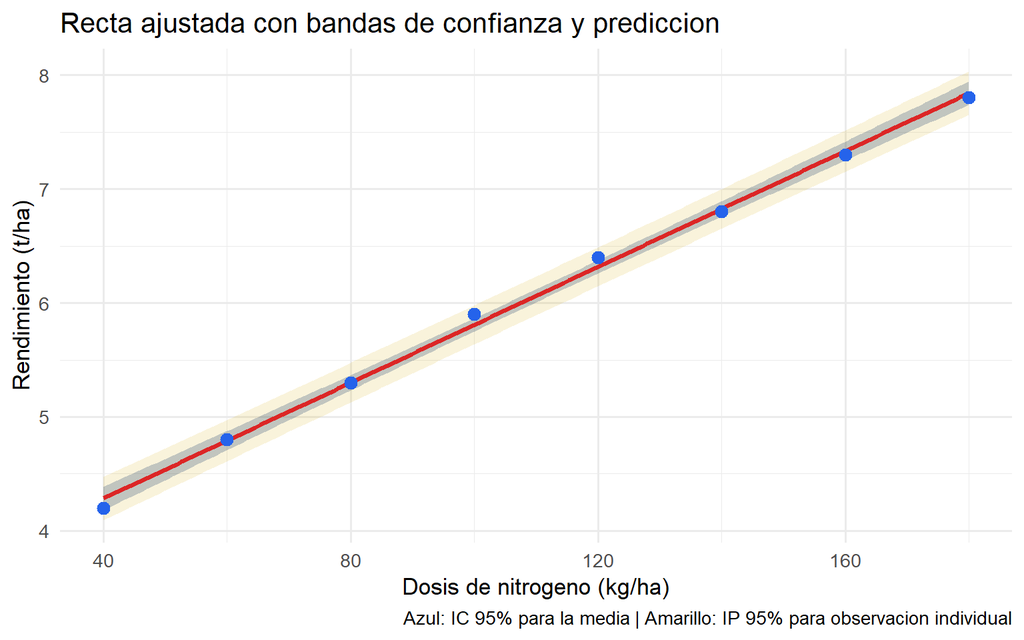

```r
rango_x  <- data.frame(nitrogeno = seq(min(datos$nitrogeno),
                                       max(datos$nitrogeno), length.out = 200))
banda_ic <- as.data.frame(predict(modelo, newdata = rango_x, interval = "confidence"))
banda_ip <- as.data.frame(predict(modelo, newdata = rango_x, interval = "prediction"))

df_bandas <- data.frame(
  x      = rango_x$nitrogeno,
  ic_lwr = banda_ic$lwr, ic_upr = banda_ic$upr, ic_fit = banda_ic$fit,
  ip_lwr = banda_ip$lwr, ip_upr = banda_ip$upr
)

ggplot() +
  geom_ribbon(data = df_bandas, aes(x = x, ymin = ip_lwr, ymax = ip_upr),
              fill = "#d4ac0d", alpha = 0.15) +
  geom_ribbon(data = df_bandas, aes(x = x, ymin = ic_lwr, ymax = ic_upr),
              fill = "#1a3a6b", alpha = 0.25) +
  geom_line(data = df_bandas, aes(x = x, y = ic_fit),
            color = "#dc2626", linewidth = 1.2) +
  geom_point(data = datos, aes(x = nitrogeno, y = rendimiento),
             color = "#2563eb", size = 3) +
  labs(
    title   = "Recta ajustada con bandas de confianza y prediccion",
    x       = "Dosis de nitrogeno (kg/ha)",
    y       = "Rendimiento (t/ha)",
    caption = "Azul: IC 95% para la media | Amarillo: IP 95% para observacion individual"
  ) +
  theme_minimal(base_size = 13)
```

## 9. Tabla resumen del analisis

```r
fstat <- summary(modelo)$fstatistic
pval_F <- pf(fstat[1], fstat[2], fstat[3], lower.tail = FALSE)

tab <- data.frame(
  Elemento = c(
    "Intercepto b0",
    "Pendiente b1",
    "R2",
    "R2 ajustado",
    "Error estandar residual",
    "Estadistico F",
    "Valor p (F)"
  ),
  Valor = c(
    round(coef(modelo)[1], 4),
    round(coef(modelo)[2], 6),
    round(summary(modelo)$r.squared, 4),
    round(summary(modelo)$adj.r.squared, 4),
    round(summary(modelo)$sigma, 4),
    round(fstat[1], 2),
    format.pval(pval_F, digits = 4)
  )
)
mostrar_tabla(tab, caption = "Resumen del modelo de regresion lineal simple")
```

Resumen del modelo de regresion lineal simple

| Elemento | Valor |
| --- | --- |
| Intercepto b0 | 3.2667 |
| Pendiente b1 | 0.025417 |
| R2 | 0.9976 |
| R2 ajustado | 0.9972 |
| Error estandar residual | 0.0656 |
| Estadistico F | 2520.68 |
| Valor p (F) | 4.188e-09 |

## 10. Implementacion completa en R

A continuacion se presenta el codigo completo del analisis tal como se presento en clase.

```r
#=========================================
# 1. Ingreso de los datos
#=========================================
nitrogeno   <- c(40, 60, 80, 100, 120, 140, 160, 180)
rendimiento <- c(4.2, 4.8, 5.3, 5.9, 6.4, 6.8, 7.3, 7.8)
datos <- data.frame(nitrogeno, rendimiento)

#=========================================
# 2. Exploracion grafica
#=========================================
plot(rendimiento ~ nitrogeno, data = datos,
     pch = 19, col = "#2563eb", cex = 1.4,
     xlab = "Dosis de nitrogeno (kg/ha)",
     ylab = "Rendimiento (t/ha)")
abline(lm(rendimiento ~ nitrogeno, data = datos),
       col = "#dc2626", lwd = 3)

#=========================================
# 3. Ajuste del modelo
#=========================================
modelo <- lm(rendimiento ~ nitrogeno, data = datos)
summary(modelo)
confint(modelo)

#=========================================
# 4. Diagnostico grafico
#=========================================
par(mfrow = c(1, 3))
plot(modelo, which = 1:3, pch = 19, col = "#1a3a6b")

#=========================================
# 5. Pruebas de supuestos
#=========================================
shapiro.test(residuals(modelo))
library(lmtest)
bptest(modelo)
dwtest(modelo)

#=========================================
# 6. Predicciones
#=========================================
nuevos <- data.frame(nitrogeno = c(50, 110, 170))
predict(modelo, newdata = nuevos)
predict(modelo, newdata = nuevos, interval = "confidence")
predict(modelo, newdata = nuevos, interval = "prediction")
```

## 11. Ejercicios propuestos

Utilice los datos del ejemplo de la clase (o los datos del taller en clase) para responder las siguientes preguntas. Incluya el codigo R, los resultados y su interpretacion.

**Ejercicio 1.** Con los datos del experimento de fertilizacion nitrogenada, calcule manualmente $b_1$ y $b_0$ usando las formulas MCO vistas en clase. Construya la tabla auxiliar con las columnas $(X_i - \bar{X})$, $(Y_i - \bar{Y})$, $(X_i - \bar{X})(Y_i - \bar{Y})$ y $(X_i - \bar{X})^2$. Compare sus resultados con los de `lm()`.

**Ejercicio 2.** Ajuste el modelo en R y reporte la ecuacion de la recta estimada. Interprete el intercepto y la pendiente en el contexto del problema (fertilizacion nitrogenada y rendimiento del maiz).

**Ejercicio 3.** El coeficiente de la pendiente es estadisticamente significativo al nivel del 5%? Justifique con el valor $p$ y el intervalo de confianza al 95%.

**Ejercicio 4.** Que porcentaje de la variabilidad del rendimiento es explicado por la dosis de nitrogeno? El valor obtenido es alto o bajo? Que significa esto?

**Ejercicio 5.** Examine los graficos de diagnostico. Se cumplen los supuestos de linealidad, homocedasticidad y normalidad? Respalde su respuesta con las pruebas de Shapiro-Wilk, Breusch-Pagan y Durbin-Watson.

**Ejercicio 6.** Prediga el rendimiento esperado para una dosis de 130 kg/ha de nitrogeno. Reporte el intervalo de confianza y el intervalo de prediccion al 95%. Por que el intervalo de prediccion es mas ancho que el de confianza?

**Ejercicio 7.** El investigador desea aplicar 250 kg/ha de nitrogeno. Seria apropiado usar este modelo para predecir el rendimiento en ese caso? Justifique.

**Ejercicio 8 (Taller en clase).** Con los datos del cafe en Antioquia (ejercicio 1 del taller en clase):

| X: Nitrogeno (kg/ha) | Y: Rendimiento cafe (kg/ha) |
| --- | --- |
| 50 | 1800 |
| 80 | 2200 |
| 100 | 2500 |
| 120 | 2700 |
| 150 | 3100 |

1. Ajuste el modelo de regresion lineal simple en R.
2. Interprete los coeficientes.
3. Evalúe los supuestos del modelo.
4. Prediga el rendimiento para una dosis de 110 kg/ha.